# Project 03

Instructor: Jill E. Thomley (thomleyje@appstate.edu)

Updated: Friday, November 30, 2018 @ 12:55:59 PM

### Problem

Nearly all fish contain some trace of mercury. For most people, this is not a serious health concern, but higher levels of mercury can harm the developing nervous systems of fetuses or young children and its effects when consumed can be cumulative. The Food and Drug Administration (FDA) and the Environmental Protection Agency (EPA) advise women who may become pregnant, pregnant women, nursing mothers, and young children to avoid some types of fish and eat others that are known to be lower in mercury. The EPA has [guidelines](https://www.epa.gov/fish-tech/epa-fda-fish-advice-technical-information) about how much is considered safe to eat. Commercial fish is regularly tested, but wild-caught fish is harder to regulate. However, officials periodically sample local sources to assess the current level of risk from fish caught there.

| Weekly fish servings | Screening value (µg/g) | Chart category |
| --- | --- | --- |
| 0 | > 0.46 | Avoid |
| 1 | ≤ 0.46 | Good |
| 2 | ≤ 0.23 | Good |
| 3 | ≤ 0.15 | Best |

The dataset [FishMercury](https://raw.githubusercontent.com/STAT-JET-ASU/Datasets/master/Chihara/FishMercury.csv) contains data for a sample of one frequently-consumed species of fish caught in a local lake. Mercury measurements are in parts per million (1 ppm = 1 µg/g).

### Your Analyses

1. Compute the sample size, mean, standard deviation, median, and 5% trimmed mean for the sample using `summarize` in `dplyr`. Create a boxplot using `ggplot2`. You do not need a title or different axis labels.

```r
mercsumm <- fishdata %>% summarize(n     = n(),
                                   xbar  = mean(Mercury),
                                   stdv  = sd(Mercury),
                                   med   = median(Mercury),
                                   xbar5 = mean(Mercury, trim = 5))
print.data.frame(mercsumm)
```

```
   n      xbar      stdv   med xbar5
1 30 0.1818667 0.3216053 0.129 0.129
```

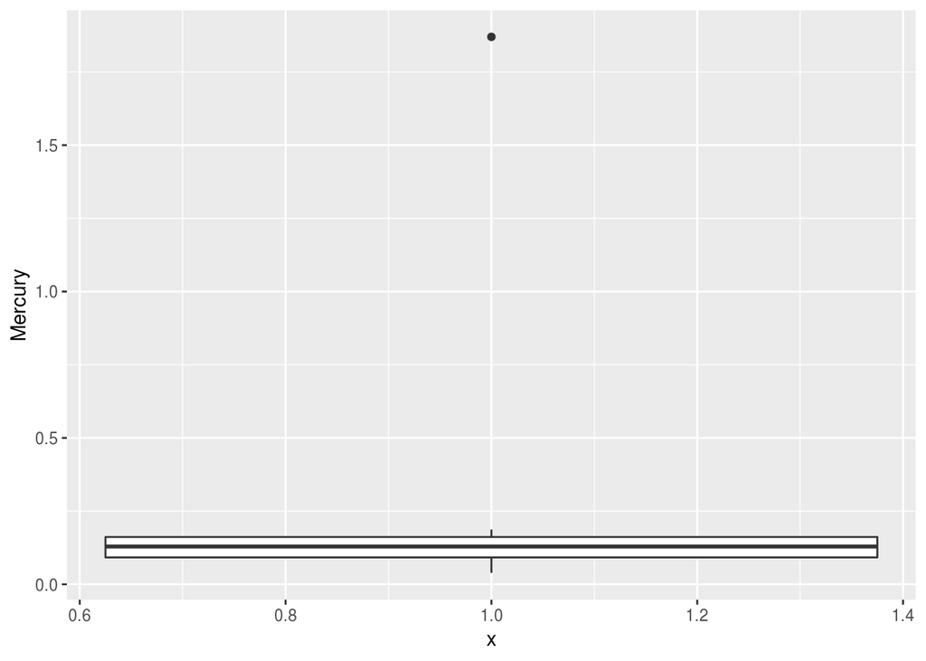

```r
ggplot(fishdata, aes(x = 1, y = Mercury)) + geom_boxplot()
```

2. A common rule for determining when we can use the central limit theorem is n ≥ 30. Since that is true in this instance, compute a traditional 95% confidence interval to estimate the true mean level of mercury for this species of fish in the sampled lake.

```r
t.test(fishdata$Mercury)
```

```
    One Sample t-test

data:  fishdata$Mercury
t = 3.0974, df = 29, p-value = 0.004307
alternative hypothesis: true mean is not equal to 0
95 percent confidence interval:
 0.06177727 0.30195607
sample estimates:
mean of x
0.1818667
```

```r
mercsumm$xbar + qt(c(0.025, 0.975), mercsumm$n - 1) * mercsumm$stdv/sqrt(mercsumm$n)
```

```
[1] 0.06177727 0.30195607
```

3. Compute a bootstrap 95% percentile interval to estimate the true mean level of mercury for this species of fish in the sampled lake. Do not include any plots in this section.

```r
merc <- fishdata$Mercury

N        <- 10^4
bootmean <- numeric(N)

for (i in 1:N){
  bootsample <- sample(merc, length(merc), replace = TRUE)
  bootmean[i] <- mean(bootsample)
}

quantile(bootmean, c(0.025, 0.975))
```

```
     2.5%     97.5%
0.1125000 0.3071342
```

4. Assess your bootstrap sampling distribution of $\bar{x}$ for normality using a density plot, an ECDF plot, and a quantile-quantile plot. Include red reference curves for the theoretical normal distribution.

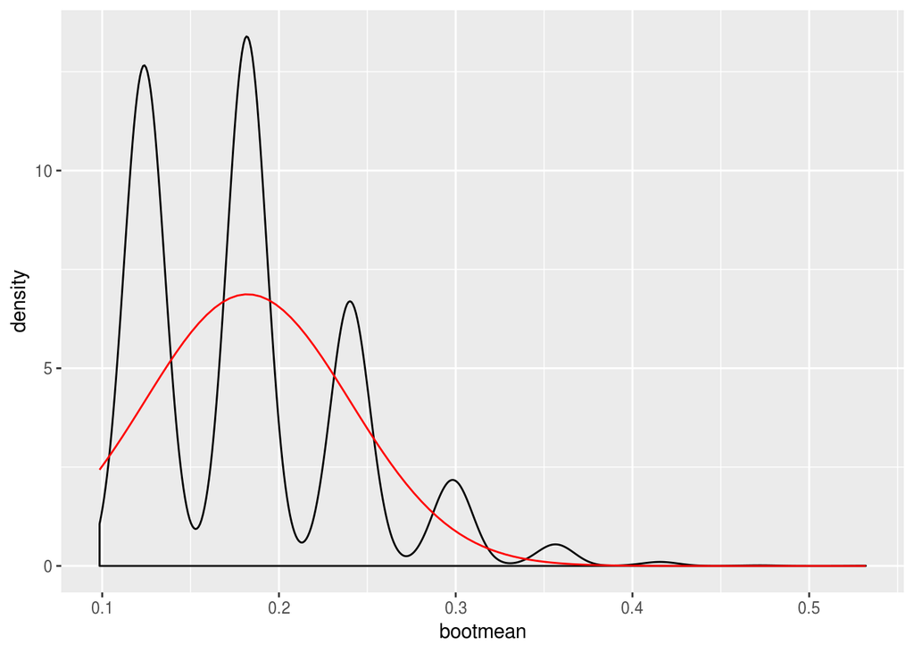

```r
ggplot(NULL, aes(x = bootmean)) +
  geom_density() +
  stat_function(fun = dnorm, args = list(mean(bootmean), sd(bootmean)), color = "red")
```

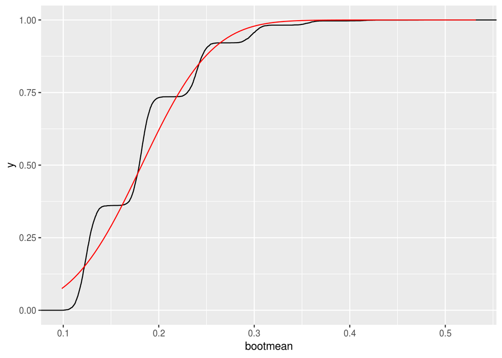

```r
ggplot(NULL, aes(x = bootmean)) +
  stat_ecdf() +
  stat_function(fun = pnorm, args = list(mean(bootmean), sd(bootmean)), color = "red")
```

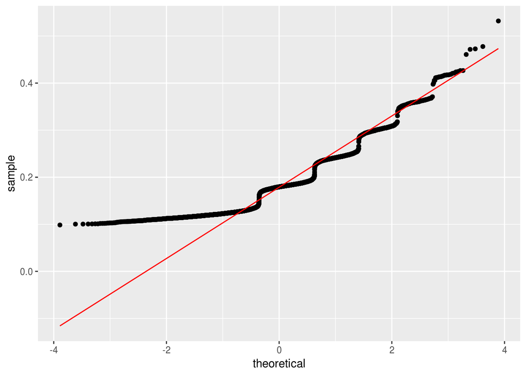

```r
ggplot(NULL, aes(sample = bootmean)) +
  stat_qq() + stat_qq_line(color = "red")
```

5. Create an ordered factor variable called `safety` that categorizes fish in the sample as “Best”, “Good”, or “Avoid”. Then create a barplot to display that variable. Include an informative title and axis labels.

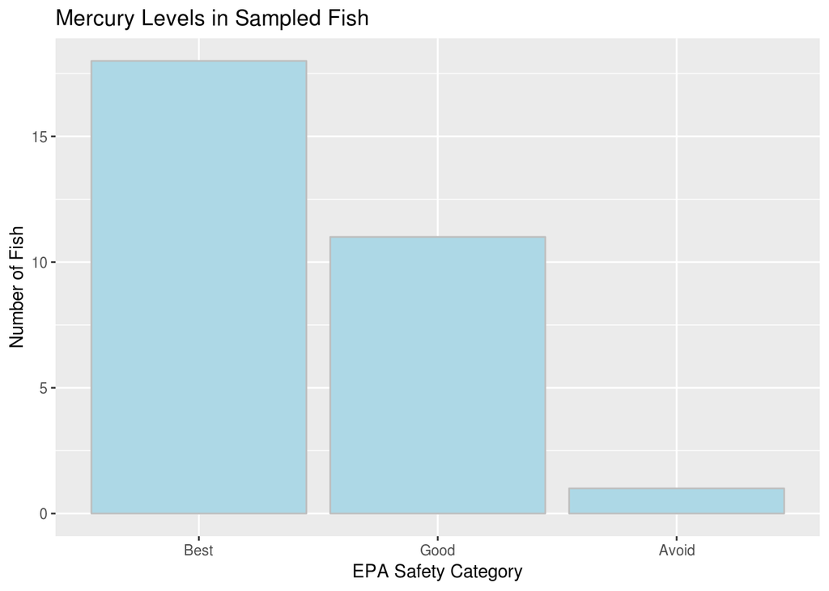

```r
fishdata <- fishdata %>%
  mutate(safety = factor(case_when(Mercury <= 0.15 ~ "Best",
                                   Mercury <= 0.46 & Mercury > 0.15 ~ "Good",
                                   Mercury > 0.46 ~ "Avoid"),
                         levels = c("Best", "Good", "Avoid")
  ))
ggplot(fishdata, aes(x = safety)) + geom_bar(fill = "lightblue", color = "gray") +
  labs(title = "Mercury Levels in Sampled Fish", x = "EPA Safety Category", y = "Number of Fish")
```

6. Compute a bootstrap 95% percentile interval to estimate the true proportion of this species of fish that fall into the “best” category. Do not include any plots in this section.

```r
safecat <- fishdata$safety

N        <- 10^4
bootprop <- numeric(N)

for (i in 1:N){
  bootsample <- sample(safecat, length(safecat), replace = TRUE)
  bootprop[i] <- mean(bootsample == "Best")
}

quantile(bootprop, c(0.025, 0.975))
```

```
     2.5%     97.5%
0.4333333 0.7666667
```

7. Why are your intervals in (2) and (3) different? Is it appropriate to the CLT for these data? Expain using the results of (1) and (4).

8. Assuming this is a representative sample, can we confidently say a majority of all fish of this species in the lake have fewer than 0.15 µg/g of mercury? Why or why not?

END PROJECT 3